# caching

### Imagine you are working at Intel in the 1980s

Circles: Processor  
Diamonds: Memory

Image from “Computer Architecture: A Quantitative Approach”

### Imagine you are working at Intel in the 1980s

The “Memory Wall”

Image from “Computer Architecture: A Quantitative Approach”

### Imagine you are working at Intel in the 1980s

The “Memory Wall”

Image from “Computer Architecture: A Quantitative Approach”

1989: Intel 80486  
with 8 KB cache

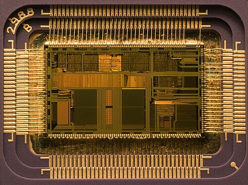

### the place of cache

[figure not shown]

### memory hierarchy

[figure not shown]

Image: approx 2004 AMD press image of Opteron die;  
approx register location via chip-architect.org (Hans de Vries)

### memory hierarchy goals

- *performance* of the fastest (smallest) memory
- *capacity* of the largest (slowest) memory
- how to hide 100x latency difference?
  - 99+% hit rate (“hit” means value found in cache)

### memory hierarchy assumptions

- *temporal locality*  
  ‘‘if a value is accessed now, it will be accessed again soon’’
  - caches should keep *recently accessed values*
- *spatial locality*  
  ‘‘if a value is accessed now, adjacent values will be accessed soon’’
  - caches should *store adjacent values at the same time*
- natural properties of programs — think about loops

### locality examples

```c
double computeMean(int length, double *values) {
    double total = 0.0;
    for (int i = 0; i < length; ++i) {
        total += values[i];
    }
    return total / length;
}
```

- temporal locality: machine code of the loop
- spatial locality: machine code of most consecutive instructions
- temporal locality: `total`, `i`, `length` accessed repeatedly
- spatial locality: `values[i+1]` accessed after `values[i]`

### locality exercise (1)

```c
/* version 1 */
for (int i = 0; i < N; ++i)
    for (int j = 0; j < N; ++j)
        A[i] += B[j] * C[i * N + j]

/* version 2 */
for (int j = 0; j < N; ++j)
    for (int i = 0; i < N; ++i)
        A[i] += B[j] * C[i * N + j];
```

- exercise: which has better temporal locality in A? in B? in C?
- how about spatial locality?

### locality exercise (2)

```c
/* version 1 */
for (int i = 0; i < N; ++i)
    for (int j = 0; j < N; ++j)
        A[i] += B[j] * C[i * N + j]

/* version 3 */
for (int ii = 0; ii < N; ii += 32)
    for (int jj = 0; jj < N; jj += 32)
        for (int i = ii; i < ii + 32; ++i)
            for (int j = jj; j < jj + 32; ++j)
                A[i] += B[j] * C[i * N + j];
```

- exercise: which has better temporal locality in A? in B? in C?
- how about spatial locality?

### locality exercise (3)

```c
struct Student {
    char name[128]; long id; float grade;
};
struct Student students[1000];

float averageGrade() {
    float sum = 0.0
    for (int i = 0; i < 1000; i += 1)
        sum += students[i].grade;
    return sum / 1000.0;
}
```

```c
char studentNames[1000][128];
long studentIds[1000];
float studentGrades[1000];

float average() {
    float sum = 0.0
    for (int i = 0; i < 1000; i += 1)
        sum += studentGrades[i];
    return sum / 1000.0;
}
```

better spatial/temporal locality?

### split caches; multiple cores (one design)

[figure not shown]

### hierarchy and instruction/data caches

- typically separate data and instruction caches for L1
- (almost) never going to read instructions as data or vice-versa
- avoids instructions evicting data and vice-versa
- can optimize instruction cache for different access pattern
- easier to build fast caches: handle fewer accesses at a time

### cache analogy: you finding words in books

- library: main memory
  - contains all the words in all books
- copy of books you took home: L2 cache
  - faster to look in books already at home
- copy of individual book pages in your backpack: L1 cache
  - fastest to look at book pages you have with you

### one-block cache

[figure not shown]

### building a (direct-mapped) cache

[figure not shown]

### terminology

- row = set
  - preview: change how much is in a row

### cache analogy: you finding words in books

block size is 1 book page

- book title: tag
- page number: index
- word index on book page: offset

### Tag-Index-Offset (TIO)

[figure not shown]

### cache size

- cache size = amount of *data* in cache
- not included metadata (tags, valid bits, etc.)

### Tag-Index-Offset formulas (direct-mapped)

(formulas derivable from prior slides)

| $S=2^s$ | number of sets |
| --- | --- |
| $s$ | (set) index bits |
| $B=2^b$ | block size |
| $b$ | (block) offset bits |
| $m$ | memory addreses bits |
| $t = m - (s+b)$ | tag bits |
| $C = B \times{} S$ | cache size (if direct-mapped) |

### TIO: exercise

- 64-byte blocks, 128 set cache
- stores $64 \times 128 = 8192$ bytes (of data)
- if addresses 32-bits, then how many tag/index/offset bits?
- which bytes are stored in the same block as byte from `0x1037`?
  - A. byte from `0x1011`
  - B. byte from `0x1021`
  - C. byte from `0x1035`
  - D. byte from `0x1041`

### cache size exercise

- A system uses a direct-mapped cache with 32 byte blocks.
- Two memory accesses are made:
  - Read `0x08249`
  - Read `0x0c658`
- What is the fewest number of cache sets this cache could have to store both values at the same time?
- What is the size of this cache?

### example access pattern (setup)

[output not shown]

2 byte blocks, 4 sets

| index | valid | tag | value |
| --- | --- | --- | --- |
| 00 |  |  |  |
| 01 |  |  |  |
| 10 |  |  |  |
| 11 |  |  |  |

$B = 2 = 2^b$ byte-block size  
$b = 1$ (block) offset bits  
$S = 4 = 2^s$ sets  
$s = 2$ (set) index bits

$m$ = 8 bit addresss  
$t = m - (s + b) = 5$ tag bits

### example access pattern (steps 1-4)

| address (as hex) |  |  |  | result |
| --- | --- | --- | --- | --- |
| 00000 | 00 | 0 | (00) | miss |
| 00000 | 00 | 1 | (01) | hit |
| 01100 | 01 | 1 | (63) | miss |
| 01100 | 00 | 1 | (61) | miss |
| 01100 | 01 | 0 | (62) |  |
| 00000 | 00 | 0 | (00) |  |
| 01100 | 10 | 0 | (64) |  |

| tag | index | offset |
| --- | --- | --- |

2 byte blocks, 4 sets

| index | valid | tag | value |
| --- | --- | --- | --- |
| 00 | 1 | 00000 | mem[0x00] mem[0x01] |
| 01 | 1 | 01100 | mem[0x62] mem[0x63] |
| 10 |  |  |  |
| 11 |  |  |  |

- access to `0x61` matches set index `00`
- block’s tag `00000` != 0x61’s tag of `01100`
- need to *replace* value in that block

### example access pattern (steps 4-7)

| address (as hex) |  |  |  | result |
| --- | --- | --- | --- | --- |
| 00000 | 00 | 0 | (00) | miss |
| 00000 | 00 | 1 | (01) | hit |
| 01100 | 01 | 1 | (63) | miss |
| 01100 | 00 | 1 | (61) | miss |
| 01100 | 01 | 0 | (62) | hit |
| 00000 | 00 | 0 | (00) | miss |
| 01100 | 10 | 0 | (64) |  |

| tag | index | offset |
| --- | --- | --- |

2 byte blocks, 4 sets

| index | valid | tag | value |
| --- | --- | --- | --- |
| 00 | 1 | 01100 | mem[0x60] mem[0x61] |
| 01 | 1 | 01100 | mem[0x62] mem[0x63] |
| 10 |  |  |  |
| 11 |  |  |  |

- access to `0x00` is miss even though:
  - we had extra space in the cache to store blocks
  - we previously accesses the `0x00-0x01` block
- called “conflict miss” (versus “compulsory” or “capacity” miss)

### aside: miss types

- compulsory:
  - first access to block
  - avoid by increasing block size or “prefetching”
- capacity:
  - trying to put too much stuff in the cache
  - avoid with larger cache
- conflict:
  - index bits happen to match up too often
  - avoid with more “associative” cache (next topic)

### example access pattern (steps 7-8)

| address (as hex) |  |  |  | result |
| --- | --- | --- | --- | --- |
| 00000 | 00 | 0 | (00) | miss |
| 00000 | 00 | 1 | (01) | hit |
| 01100 | 01 | 1 | (63) | miss |
| 01100 | 00 | 1 | (61) | miss |
| 01100 | 01 | 0 | (62) | hit |
| 00000 | 00 | 0 | (00) | miss |
| 01100 | 10 | 0 | (64) | miss |

| tag | index | offset |
| --- | --- | --- |

2 byte blocks, 4 sets

[output not shown]

- place 0x00-0x01 back in cache set 0
- would have been better if never replaced…
- … but cache can’t see the future to know that

### direct-mapped cache exercise (1)

| address (as hex) |  |  |  | result |
| --- | --- | --- | --- | --- |
| 0000 | 00 | 00 | (00) |  |
| 0000 | 00 | 01 | (01) |  |
| 0110 | 00 | 11 | (63) |  |
| 0110 | 00 | 01 | (61) |  |
| 0110 | 00 | 10 | (62) |  |
| 0000 | 00 | 00 | (00) |  |
| 0110 | 01 | 00 | (64) |  |

| tag | index | offset |
| --- | --- | --- |

*4* byte blocks, 4 sets

| index | valid | tag | value |
| --- | --- | --- | --- |
| 00 |  |  |  |
| 01 |  |  |  |
| 10 |  |  |  |
| 11 |  |  |  |

exercise: how to split addresses?

### solution

- $4 = 2^b$ byte block size
- $b = 2$ (block) offset bits
- $S = 4 = 2^s$ sets
- $s = 2$ (set) index bits
- $m = 8$ bit addresses
- $t = m - (s+b) = 4$ tag bits

### direct-mapped cache exercise (2)

| address (as hex) |  |  |  | result |
| --- | --- | --- | --- | --- |
| 0000 | 00 | 00 | (00) |  |
| 0000 | 00 | 01 | (01) |  |
| 0110 | 00 | 11 | (63) |  |
| 0110 | 00 | 01 | (61) |  |
| 0110 | 00 | 10 | (62) |  |
| 0000 | 00 | 00 | (00) |  |
| 0110 | 01 | 00 | (64) |  |

| tag | index | offset |
| --- | --- | --- |

*4* byte blocks, 4 sets

| index | valid | tag | value |
| --- | --- | --- | --- |
| 00 |  |  |  |
| 01 |  |  |  |
| 10 |  |  |  |
| 11 |  |  |  |

exercise: which accesses are hits?

### exercise

[figure not shown]

### mapping of sets to memory (direct-mapped)

[figure not shown]

### simulated misses: BST lookups

[figure not shown]

simulated 16KB direct-mapped cache; excluding BST setup

### actual misses: BST lookups

[figure not shown]

actual 32KB more complex cache (only one set of measurements + other things on the machine + excluding initial load)

### simulated misses: matrix multiplies

[figure not shown]

simulated 16KB direct-mapped data cache; excluding initial load

### actual misses: matrix multiplies

[figure not shown]

actual 32KB more complex cache; excluding initial matrix load

### adding associativity

[figure not shown]

### associative lookup possibilities

- none of the blocks for the index are valid
- none of the valid blocks for the index match the tag
  - something else is stored there
- one of the blocks for the index is valid and matches the tag

### associativity accesses example (steps 1-7)

2-way set associtiative, 2 byte blocks, 2 sets

| index | valid | tag | value |  | valid | tag | value |
| --- | --- | --- | --- | --- | --- | --- | --- |
| 0 | 1 | 000000 | mem[0x00] mem[0x01] |  | 1 | 011000 | mem[0x60] mem[0x61] |
| 1 | 1 | 011000 | mem[0x62] mem[0x63] |  |  |  |  |

| address (as hex) |  |  |  | result |
| --- | --- | --- | --- | --- |
| 000000 | 0 | 0 | (00) | miss |
| 000000 | 0 | 1 | (01) | hit |
| 011000 | 1 | 1 | (63) | miss |
| 011000 | 0 | 1 | (61) | miss |
| 011000 | 1 | 0 | (62) | hit |
| 000000 | 0 | 0 | (00) | hit |
| 011001 | 0 | 0 | (64) | miss |

| tag | index | offset |
| --- | --- | --- |

for 0x64, need to replace something in set `0`  
question: which way?

### cache operation (associative)

[figure not shown]

### least recently used

[figure not shown]

### LRU bit updating

[figure not shown]

### LRU w/ more than two ways?

- need to track total order
- worst case: bunch of new accesses to same set
  - first replaces least recently used
  - next replaces next least recently used
  - etc.

3-way set associtiative, 2 byte blocks, 2 sets

| index | valid | tag | value |  | valid | tag | value |  | valid | tag | value | LRU |
| --- | --- | --- | --- | --- | --- | --- | --- | --- | --- | --- | --- | --- |
| 0 | 1 | … | … |  | 1 | … | … |  | 1 | … | … | 0 then 1 |
| 0 | 1 | … | … |  | 1 | … | … |  | 1 | … | … | 2 then 0 |

- hard to track, so frequently only approximated

### example replacement policies

- least recently used
  - take advantage of *temporal locality*
  - at least $\left\lceil{}\log_2(E!)\right\rceil$ bits per set for $E$-way cache
    - (need to store order of all blocks)
- approximations of least recently used
  - implementing least recently used is expensive
  - really just need ‘‘avoid recently used’’ — much faster/simpler
  - good approximations: $E$ to $2E$ bits
- first-in, first-out
  - counter per set — where to replace next
- (pseudo-)random
  - no extra information!
  - actually works pretty well in practice

### associativity terminology

- *direct-mapped* — one block per set
- *$E$-way set associative* — $E$ blocks per set
  - $E$ ways in the cache
- *fully associative* — one set total (everything in one set)

### Tag-Index-Offset formulas

| $m$ | memory addreses bits |
| --- | --- |
| $E$ | number of blocks per set (‘‘ways’’) |
| $S=2^s$ | number of sets |
| $s$ | (set) index bits |
| $B=2^b$ | block size |
| $b$ | (block) offset bits |
| $t = m - (s+b)$ | tag bits |
| $C = B \times S \times E$ | cache size (excluding metadata) |

### C and cache misses (1)

```c
int array[4];
...
int even_sum = 0, odd_sum = 0;
even_sum += array[0];
odd_sum += array[1];
even_sum += array[2];
odd_sum += array[3];
```

- Assume everything but `array` is kept in registers (and the compiler does not do anything funny).
- How many data cache misses on a 1-set direct-mapped cache with 8B blocks?

### some possibilities

[figure not shown]

### aside: alignment

- compilers and malloc/new implementations usually try to *align* values
- align = make address be multiple of something
- most important reason: don’t cross cache block boundaries

### C and cache misses (2)

```c
int array[4];
int even_sum = 0, odd_sum = 0;
even_sum += array[0];
even_sum += array[2];
odd_sum += array[1];
odd_sum += array[3];
```

- Assume everything but `array` is kept in registers (and the compiler does not do anything funny).
- Assume `array[0]` at beginning of cache block.
- How many data cache misses on a 1-set direct-mapped cache with 8B blocks?

### exercise solution

[figure not shown]

### C and cache misses (3)

```c
int array[8]; /* assume aligned */
...
int even_sum = 0, odd_sum = 0;
even_sum += array[0];
even_sum += array[2];
even_sum += array[4];
even_sum += array[6];
odd_sum += array[1];
odd_sum += array[3];
odd_sum += array[5];
odd_sum += array[7];
```

- Assume everything but `array` is kept in registers (and the compiler does not do anything funny).
- How many data cache misses on a *2*-set direct-mapped cache with 8B blocks?

### exercise solution

[figure not shown]

### C and cache misses (4)

```c
int array[8]; /* assume aligned */
...
int even_sum = 0, odd_sum = 0;
even_sum += array[0];
odd_sum += array[3];
even_sum += array[6];
odd_sum += array[1];
even_sum += array[4];
odd_sum += array[7];
even_sum += array[2];
odd_sum += array[5];
```

- Assume everything but `array` is kept in registers (and the compiler does not do anything funny).
- How many data cache misses on a *2*-set direct-mapped cache with 8B blocks?

### C and cache misses (5)

```c
int array[1024]; /* assume aligned */ int even = 0, odd = 0;
even += array[0];
even += array[2];
even += array[512];
even += array[514];
odd += array[1];
odd += array[3];
odd += array[511];
odd += array[513];
```

Assume everything but `array` is kept in registers (and the compiler does not do anything funny).  
observation: `array[0]` and `array[512]` exactly 2KB apart

- How many data cache misses on a 2KB direct mapped cache with 16B blocks?

### C and cache misses (6)

```c
int array[1024]; /* assume aligned */ int even = 0, odd = 0;
even += array[0];
even += array[2];
even += array[500];
even += array[502];
odd += array[1];
odd += array[3];
odd += array[501];
odd += array[503];
```

Assume everything but `array` is kept in registers (and the compiler does not do anything funny).

- How many data cache misses on a 2KB direct mapped cache with 16B blocks?

### misses with skipping

```c
int array1[512]; int array2[512];
...
for (int i = 0; i < 512; i += 1)
    sum += array1[i] * array2[i];
}
```

- Assume everything but `array1`, `array2` is kept in registers (and the compiler does not do anything funny).
- About how many *data cache misses* on a 2KB direct-mapped cache with 16B cache blocks?  
  Hint: depends on relative placement of `array1`, `array2`

### best/worst case

- `array1[i]` and `array2[i]` always different sets:
  - = distance from `array1` to `array2` not multiple of `#sets` $\times$ `bytes/set`
  - 2 misses every 4 `i`
  - blocks of 4 `array1[X]` values loaded, then used 4 times before loading next block
  - (and same for `array2[X]`)
- `array1[i]` and `array2[i]` same sets:
  - = distance from `array1` to `array2` is multiple of `#sets` $\times$ `bytes/set`
  - 2 misses every `i`
  - block of 4 `array1[X]` values loaded, one value used from it,
  - then, block of 4 `array2[X]` values replaces it, one value used from it, …

### worst case in practice?

- can have worst spacing happen by accident:
- two structs/arrays placed at start of newly allocated page
  - worst-case spacing likely small multiple of page size
- columns of matrix with power-of-two width

### mapping of sets to memory (3-way)

[figure not shown]

### C and cache misses (assoc)

```c
int array[1024]; /* assume aligned */
int even_sum = 0, odd_sum = 0;
even_sum += array[0];
even_sum += array[2];
even_sum += array[512];
even_sum += array[514];
odd_sum += array[1];
odd_sum += array[3];
odd_sum += array[511];
odd_sum += array[513];
```

Assume everything but `array` is kept in registers (and the compiler does not do anything funny).  
observation: `array[0]`, `array[256]`, `array[512]`, `array[768]` in same set

- How many data cache misses on a 2KB 2-way set associative cache with 16B blocks?

### C and cache misses (assoc)

```c
int array[1024]; /* assume aligned */
int even_sum = 0, odd_sum = 0;
even_sum += array[0];
even_sum += array[256];
even_sum += array[512];
even_sum += array[768];
odd_sum += array[1];
odd_sum += array[257];
odd_sum += array[513];
odd_sum += array[769];
```

Assume everything but `array` is kept in registers (and the compiler does not do anything funny).  
observation: `array[0]`, `array[256]`, `array[512]`, `array[768]` in same set

- How many data cache misses on a 2KB 2-way set associative cache with 16B blocks?

### handling writes

- what about writing to the cache?
- two decision points:
- if the value is not in cache, do we add it?
  - if yes: need to load rest of block — *write-allocate*
  - if no: missing out on locality? *write-no-allocate*
- if value is in cache, when do we update next level?
  - if immediately: extra writing *write-through*
  - if later: need to remember to do so *write-back*

### allocate on write?

- say processor writes *less than whole* cache block
- and block not yet in cache
- two options:
- *write-allocate*
  - fetch rest of cache block, replace written part
  - (then follow write-through or write-back policy)
- *write-no-allocate*
  - don’t use cache at all (send write to memory *instead*)
  - guess: not read soon?

### write-allocate v. write-no-allocate

[figure not shown]

### write-through v. write-back

[figure not shown]

### write-back policy

[figure not shown]

### write-allocate + write-back

[figure not shown]

### write-no-allocate + write-back

[figure not shown]

### cache write exercise (1)

[figure not shown]

- for each of the following accesses, performed alone, would it require (a) reading a value from memory (or next level of cache) and (b) writing a value to the memory (or next level of cache)?
  - writing 1 byte to 0x33
  - reading 1 byte from 0x52
  - reading 1 byte from 0x50

### cache write exercise (1, solution)

[figure not shown]

- writing 1 byte to 0x33: (set 1, offset 1) no next-level read or write
- reading 1 byte from 0x52: (set 1, offset 0) *write* back 0x32-0x33; *read* 0x52-0x53
- reading 1 byte from 0x50: (set 0, offset 0) replace 0x30-0x31 (no write back); *read* 0x50-0x51

### cache write exercise (2)

[figure not shown]

- for each of the following accesses, *performed alone*, would it require (a) reading a value from memory and (b) writing a value to the memory?
  - writing 1 byte to 0x33
  - reading 1 byte from 0x52
  - reading 1 byte from 0x50

### cache write exercise (2, solution)

[figure not shown]

- writing 1 byte to 0x33: (set 1, offset 1) write-through 0x33 modification
- reading 1 byte from 0x52: (set 1, offset 0) replace 0x32-0x33; *read* 0x52-0x53
- reading 1 byte from 0x50: (set 0, offset 0) replace 0x30-0x31; *read* 0x50-0x51

### fast writes with write-through caches

[figure not shown]

### cache tradeoffs briefly

- deciding cache size, associativity, etc.?
- lots of tradeoffs:
  - more cache hits v. slower cache hits?
  - faster cache hits v. fewer cache hits?
  - (N+1)th-level cache v. larger Nth level cache?
  - …
- details depend on programs run
  - how often is same block used again?
  - how often is same index bits used?
  - how much {temporal,spatial} locality to take advantage of?
- simulation to assess impact of designs

### cache organization and miss rate

- *depends on program*; one example:
- SPEC CPU2000 benchmarks, 64B block size, LRU replacement
- data cache miss rates:

  | Cache size | direct-mapped | 2-way | 8-way | fully assoc. |
  | --- | --- | --- | --- | --- |
  | 1KB | 8.63% | 6.97% | 5.63% | 5.34% |
  | 2KB | 5.71% | 4.23% | 3.30% | 3.05% |
  | 4KB | 3.70% | 2.60% | 2.03% | 1.90% |
  | 16KB | 1.59% | 0.86% | 0.56% | 0.50% |
  | 64KB | 0.66% | 0.37% | 0.10% | 0.001% |
  | 128KB | 0.27% | 0.001% | 0.0006% | 0.0006% |

### average memory access time

- $\text{AMAT} = \text{hit time} + \text{miss penalty} \times{} \text{miss rate}$
  - or $\text{AMAT} = \text{hit time} \times \text{hit rate} + \text{miss time} \times \text{miss rate}$
- effective speed of memory

### AMAT exercise (1)

- 90% cache hit rate
- hit time is 2 cycles
- 30 cycle miss penalty
- what is the average memory access time?
- 5 cycles
- suppose we could increase hit rate by increasing its size, but it would increase the hit time to 3 cycles
- how much do we have to increase the hit rate for this to not increase AMAT?
- to miss rate of 2/30 $\rightarrow$ to approx 93% hit rate

### two-level page table lookup

[figure not shown]

### another view

[figure not shown]

### cache accesses and multi-level PTs

- four-level page tables — five cache accesses per program memory access
- L1 cache hits — typically a couple cycles each?
- so add 8 cycles to each program memory access?
- not acceptable

### program memory active sets

[figure not shown]

### page table entries and locality

- page table entries have *excellent temporal locality*
- typically one or two pages of the stack active
- typically one or two pages of code active
- typically one or two pages of heap/globals active
- each page contains *whole functions*, arrays, stack frames, etc.
- needed page table entries are *very small*

### page table entry cache

- caled a *TLB* (translation lookaside buffer)
- *(usually very small) cache of page table entries*

  | L1 cache | TLB |
  | --- | --- |
  | physical addresses | virtual page numbers |
  | bytes from memory | page table entries |
  | tens of bytes per block | one page table entry per block |
  | usually thousands of blocks | usually tens of entries |

only caches the page table lookup itself  
(generally) just entries from the last-level page tables

virtual page number divided into index + tag

not much spatial locality between page table entries  
(they’re used for kilobytes of data already)

`0` block offset bits

few active page table entries at a time  
enables highly associative cache designs

### TLB and multi-level page tables

- TLB caches *valid last-level page table entries*
- doesn’t matter which last-level page table
- means TLB output can be used directly to form address

### TLB and two-level lookup

[figure not shown]

### TLB organization (2-way set associative)

[figure not shown]

### address splitting for TLBs (1)

- my desktop:
- 4KB ($2^{12}$ byte) pages; 48-bit virtual address
- 64-entry, 4-way L1 data TLB
- TLB index bits? $64/4 = 16$ sets — 4 bits
- TLB tag bits? $48-12=36$ bit virtual page number — $36-4=32$ bit TLB tag

### address splitting for TLBs (2)

- my desktop:
- 4KB ($2^{12}$ byte) pages; 48-bit virtual address
- 1536-entry ($3\cdot 2^9$), 12-way L2 TLB
- TLB index bits? $1536/12 = 128$ sets — 7 bits
- TLB tag bits? $48-12=36$ bit virtual page number — $36-7=29$ bit TLB tag

### exercise: TLB access pattern (setup)

- 4-entry, 2-way TLB, LRU replacement policy, initially empty
- 4096 byte pages
- how many index bits?
- TLB index of virtual address 0x12345?

### exercise: TLB access pattern

- 4-entry, 2-way TLB, LRU replacement policy, initially empty
- 4096 byte pages

| type | virtual | physical | result | set 0 | set 1 |
| --- | --- | --- | --- | --- | --- |
| read | 0x440030 | 0x554030 |  |  |  |
| write | 0x440034 | 0x554034 |  |  |  |
| read | 0x7FFFE008 | 0x556008 |  |  |  |
| read | 0x7FFFE000 | 0x556000 |  |  |  |
| read | 0x7FFFDFF8 | 0x5F8FF8 |  |  |  |
| read | 0x664080 | 0x5F9080 |  |  |  |
| read | 0x440038 | 0x554038 |  |  |  |
| write | 0x7FFFDFF0 | 0x5F8FF0 |  |  |  |

- which are TLB hits? which are TLB misses? final contents of TLB?

### solution: TLB access pattern

| type | virtual | physical | result | set 0 | set 1 |
| --- | --- | --- | --- | --- | --- |
| read | 0x440030 | 0x554030 | miss | 0x440 |  |
| write | 0x440034 | 0x554034 | hit | 0x440 |  |
| read | 0x7FFFE008 | 0x556008 | miss | 0x440, 0x7FFFE |  |
| read | 0x7FFFE000 | 0x556000 | hit | 0x440, 0x7FFFE |  |
| read | 0x7FFFDFF8 | 0x5F8FF8 | miss | 0x440, 0x7FFFE | 0x7FFFD |
| read | 0x664080 | 0x5F9080 | miss | 0x664, 0x7FFFE | 0x7FFFD |
| read | 0x440038 | 0x554038 | miss | 0x664, 0x440 | 0x7FFFD |
| write | 0x7FFFDFF0 | 0x5F8FF0 | hit | 0x664, 0x440 | 0x7FFFD |

[output not shown]

# Backup slides

### cache accesses and C code (1)

```c
int scaleFactor;

int scaleByFactor(int value) {
    return value * scaleFactor;
}
```

```
scaleByFactor:
    movl scaleFactor, %eax
    imull %edi, %eax
    ret
```

- exericse: what data cache accesses does this function do?
  - 4-byte read of scaleFactor
  - 8-byte read of return address

### possible scaleFactor use

```c
for (int i = 0; i < size; ++i) {
    array[i] = scaleByFactor(array[i]);
}
```

### misses and code (2)

```
scaleByFactor:
    movl scaleFactor, %eax
    imull %edi, %eax
    ret
```

- suppose each time this is called in the loop:
  - return address located at address `0x7ffffffe43b8`
  - scaleFactor located at address `0x6bc3a0`
- with direct-mapped 32KB cache w/64 B blocks, what is their:

  |  | return address | scaleFactor |
  | --- | --- | --- |
  | tag | 0xfffffffc | 0xd7 |
  | index | 0x10e | 0x10e |
  | offset | 0x38 | 0x20 |

### conflict miss coincidences?

- obviously I set that up to have the same index
  - have to use exactly the right amount of stack space…
- but one of the reasons we’ll want something better than direct-mapped cache

### C and cache misses (warmup 3)

```
int array[8];
...
int even_sum = 0, odd_sum = 0;
even_sum += array[0];
odd_sum += array[1];
even_sum += array[2];
odd_sum += array[3];
even_sum += array[4];
odd_sum += array[5];
even_sum += array[6];
odd_sum += array[7];
```

- Assume everything but `array` is kept in registers (and the compiler does not do anything funny), and `array[0]` at beginning of cache block.
- How many data cache misses on a *2*-set direct-mapped cache with 8B blocks?

### exercise solution

[figure not shown]

### arrays and cache misses (1)

```
int array[1024]; // 4KB array
int even_sum = 0, odd_sum = 0;
for (int i = 0; i < 1024; i += 2) {
    even_sum += array[i + 0];
    odd_sum +=  array[i + 1];
}
```

- Assume everything but `array` is kept in registers (and the compiler does not do anything funny).
- How many *data cache misses* on initially empty 2KB direct-mapped cache with 16B cache blocks?

### arrays and cache misses (2)

```
int array[1024]; // 4KB array
int even_sum = 0, odd_sum = 0;
for (int i = 0; i < 1024; i += 2)
    even_sum += array[i + 0];
for (int i = 0; i < 1024; i += 2)
    odd_sum +=  array[i + 1];
```

- Assume everything but `array` is kept in registers (and the compiler does not do anything funny).
- How many *data cache misses* on initially empty 2KB direct-mapped cache with 16B cache blocks?

### explanation

- 2-way, 2KB set associative cache, 16B blocks
- 4 offset bits, 6 index bits
- so addresses multiples $2^10$ bytes apart differ only in tag bits
- example: array[0$\rightarrow{}$3], array[256$\rightarrow{}$259], array[512$\rightarrow{}$515], array[768$\rightarrow{}$771]
- those all use the same set
- but sets only holds 2 things
- all misses

### arrays and cache misses (2b)

```
int array[1024]; // 4KB array
int even_sum = 0, odd_sum = 0;
for (int i = 0; i < 1024; i += 2)
    even_sum += array[i + 0];
for (int i = 0; i < 1024; i += 2)
    odd_sum +=  array[i + 1];
```

- Assume everything but `array` is kept in registers (and the compiler does not do anything funny).
- How many *data cache misses* on initially empty *4KB* direct-mapped cache with 16B cache blocks?

### simulated misses: BST lookups

[figure not shown]

### simulated misses: matrix multiplies

[figure not shown]

### inclusive versus exclusive

[figure not shown]

### Tag-Index-Offset formulas (direct-mapped)

(formulas derivable from prior slides)

| $S=2^s$ | number of sets |
| --- | --- |
| $s$ | (set) index bits |
| $B=2^b$ | block size |
| $b$ | (block) offset bits |
| $m$ | memory addreses bits |
| $t = m - (s+b)$ | tag bits |
| $C = B \times{} S$ | cache size (if direct-mapped) |

### example access pattern (1)

[figure not shown]

### cache organization and miss rate

- *depends on program*; one example:
- SPEC CPU2000 benchmarks, 64B block size, LRU replacement
- data cache miss rates:

  | Cache size | direct-mapped | 2-way | 8-way | fully assoc. |
  | --- | --- | --- | --- | --- |
  | 1KB | 8.63% | 6.97% | 5.63% | 5.34% |
  | 2KB | 5.71% | 4.23% | 3.30% | 3.05% |
  | 4KB | 3.70% | 2.60% | 2.03% | 1.90% |
  | 16KB | 1.59% | 0.86% | 0.56% | 0.50% |
  | 64KB | 0.66% | 0.37% | 0.10% | 0.001% |
  | 128KB | 0.27% | 0.001% | 0.0006% | 0.0006% |

### exercise (1)

- initial cache: 64-byte blocks, 64 sets, 8 ways/set
- If we leave the other parameters listed above unchanged, which will probably reduce the number of *capacity misses* in a typical program? (Multiple may be correct.)

  | A. | quadrupling the block size (256-byte blocks, 64 sets, 8 ways/set) |
  | --- | --- |
  | B. | quadrupling the number of sets |
  | C. | quadrupling the number of ways/set |

### exercise (2)

- initial cache: 64-byte blocks, 8 ways/set, 64KB cache
- If we leave the other parameters listed above unchanged, which will probably reduce the number of *capacity misses* in a typical program? (Multiple may be correct.)

  | A. | quadrupling the block size (256-byte block, 8 ways/set, 64KB cache) |
  | --- | --- |
  | B. | quadrupling the number of ways/set |
  | C. | quadrupling the cache size |

### exercise (3)

- initial cache: 64-byte blocks, 8 ways/set, 64KB cache
- If we leave the other parameters listed above unchanged, which will probably reduce the number of *conflict misses* in a typical program? (Multiple may be correct.)

  | A. | quadrupling the block size (256-byte block, 8 ways/set, 64KB cache) |
  | --- | --- |
  | B. | quadrupling the number of ways/set |
  | C. | quadrupling the cache size |

### prefetching

- seems like we can’t really improve cold misses…
- have to have a miss to bring value into the cache?
- solution: don’t require miss: ‘prefetch’ the value before it’s accessed
- remaining problem: how do we know what to fetch?

### common access patterns

- suppose recently accessed 16B cache blocks are at:
  - 0x48010, 0x48020, 0x48030, 0x48040
- guess what’s accessed next
- common pattern with *instruction fetches* and *array accesses*

### prefetching idea

- look for sequential accesses
- bring in guess at next-to-be-accessed value
- if right: no cache miss (even if never accessed before)
- if wrong: possibly evicted something else — could cause more misses
  - fortunately, sequential access guesses almost always right

### quiz exercise solution

[figure not shown]

### not the quiz problem

[figure not shown]

### C and cache misses (4)

```c
typedef struct {
    int a_value, b_value;
    int other_values[6];
} item;
item items[5];
int a_sum = 0, b_sum = 0;
for (int i = 0; i < 5; ++i)
    a_sum += items[i].a_value;
for (int i = 0; i < 5; ++i)
    b_sum += items[i].b_value;
```

- Assume everything but `items` is kept in registers (and the compiler does not do anything funny).

### C and cache misses (4, rewrite)

```c
int array[40]
int a_sum = 0, b_sum = 0;
for (int i = 0; i < 40; i += 8)
    a_sum += array[i];
for (int i = 1; i < 40; i += 8)
    b_sum += array[i];
```

- Assume everything but `array` is kept in registers (and the compiler does not do anything funny) and array starts at beginning of cache block.
- How many *data cache misses* on a *2-way* set associative 128B cache with 16B cache blocks and LRU replacement?

### C and cache misses (4, solution pt 1)

- ints 4 byte $\rightarrow$ array[0 to 3] and array[16 to 19] in same cache set
  - 64B = 16 ints stored per way
  - 4 sets total
- accessing 0, 8, 16, 24, 32, 1, 9, 17, 25, 33
- 0 (set 0), 8 (set 2), 16 (set 0), 24 (set 2), 32 (set 0)
- 1 (set 0), 9 (set 2), 17 (set 0), 25 (set 2), 33 (set 0)

### C and cache misses (4, solution pt 2)

| access | set 0 after (LRU first) | result |
| --- | --- | --- |
| — | —, — |  |
| array[0] | —, array[0 to 3] | miss |
| array[16] | array[0 to 3], array[16 to 19] | miss |
| array[32] | array[16 to 19], array[32 to 35] | miss |
| array1 | array[32 to 35], array[0 to 3] | miss |
| array[17] | array[0 to 3], array[16 to 19] | miss |
| array[32] | array[16 to 19], array[32 to 35] | miss |

6 misses for set 0

### C and cache misses (4, solution pt 3)

[output not shown]

### C and cache misses (3)

```c
typedef struct {
    int a_value, b_value;
    int other_values[10];
} item;
item items[5];
int a_sum = 0, b_sum = 0;
for (int i = 0; i < 5; ++i)
    a_sum += items[i].a_value;
for (int i = 0; i < 5; ++i)
    b_sum += items[i].b_value;
```

- observation: 12 ints in struct: only first two used
- equivalent to accessing array[0], array[12], array[24], etc.
- … then accessing array1, array[13], array[25], etc.

### C and cache misses (3, rewritten?)

```c
int array[60];
int a_sum = 0, b_sum = 0;
for (int i = 0; i < 60; i += 12)
    a_sum += array[i];
for (int i = 1; i < 60; i += 12)
    b_sum += array[i];
```

- Assume everything but `array` is kept in registers (and the compiler does not do anything funny) and array at beginning of cache block.
- How many *data cache misses* on a 128B two-way set associative cache with 16B cache blocks and LRU replacement?
- observation 1: first loop has 5 misses — first accesses to blocks
- observation 2: array[0] and array1, array[12] and array[13], etc. in same cache block

### C and cache misses (3)

```c
typedef struct {
    int a_value, b_value;
    int boring_values[126];
} item;
item items[8]; // 4 KB array
int a_sum = 0, b_sum = 0;
for (int i = 0; i < 8; ++i)
    a_sum += items[i].a_value;
for (int i = 0; i < 8; ++i)
    b_sum += items[i].b_value;
```

- Assume everything but `items` is kept in registers (and the compiler does not do anything funny).
- How many *data cache misses* on a 2KB direct-mapped cache with 16B cache blocks?

### C and cache misses (3, rewritten?)

```c
item array[1024]; // 4 KB array
int a_sum = 0, b_sum = 0;
for (int i = 0; i < 1024; i += 128)
    a_sum += array[i];
for (int i = 1; i < 1024; i += 128)
    b_sum += array[i];
```

### C and cache misses (4)

```c
typedef struct {
    int a_value, b_value;
    int boring_values[126];
} item;
item items[8]; // 4 KB array
int a_sum = 0, b_sum = 0;
for (int i = 0; i < 8; ++i)
    a_sum += items[i].a_value;
for (int i = 0; i < 8; ++i)
    b_sum += items[i].b_value;
```

- Assume everything but `items` is kept in registers (and the compiler does not do anything funny).
- How many *data cache misses* on a 4-way set associative 2KB direct-mapped cache with 16B cache blocks?

### thinking about cache storage (1)

- 2KB direct-mapped cache with 16B blocks —
- set 0: address 0 to 15, (0 to 15) + 2KB, (0 to 15) + 4KB, …
  - block at 0: array[0] through array[3]
  - block at 0+2KB: array[512] through array[515]
- set 1: address 16 to 31, (16 to 31) + 2KB, (16 to 31) + 4KB, …
  - block at 16: array[4] through array[7]
  - block at 16+2KB: array[516] through array[519]
- …
- set 127: address 2032 to 2047, (2032 to 2047) + 2KB, …
  - block at 2032: array[508] through array[511]
  - block at 2032+2KB: array[1020] through array[1023]

### arrays and cache misses (3)

```
int sum; int array[1024]; // 4KB array
for (int i = 8; i < 1016; i += 1) {
    int local_sum = 0;
    for (int j = i - 8; j < i + 8; j += 1) {
        local_sum += array[i] * (j - i);
    }
    sum += (local_sum - array[i]);
}
```

- Assume everything but `array` is kept in registers (and the compiler does not do anything funny).
- How many *data cache misses* on initially empty *2KB* direct-mapped cache with 16B cache blocks?

### Tag-Index-Offset exercise

| $m$ | memory addreses bits (Y86-64: 64) |
| --- | --- |
| $E$ | number of blocks per set (‘‘ways’’) |
| $S=2^s$ | number of sets |
| $s$ | (set) index bits |
| $B=2^b$ | block size |
| $b$ | (block) offset bits |
| $t = m - (s+b)$ | tag bits |
| $C = B \times{} S \times{} E$ | cache size (excluding metadata) |

- My desktop:
  - L1 Data Cache: 32 KB, 8 blocks/set, 64 byte blocks
  - L2 Cache: 256 KB, 4 blocks/set, 64 byte blocks
  - L3 Cache: 8 MB, 16 blocks/set, 64 byte blocks
  - Divide the address `0x34567` into *tag*, *index*, *offset* for each cache.

### T-I-O exercise: L1

| quantity | value for L1 |
| --- | --- |
| block size (given) | $B=64\text{Byte}$ |
| $B=2^b$ ($b$: block offset bits) |  |
| block offset bits | $b=$*$6$* |
| blocks/set (given) | $E=8$ |
| cache size (given) | $C = 32\text{KB} = E \times{} B \times{} S$ |
| $S = \frac{C}{B\times E}$ ($S$: number of sets) |  |
| number of sets | $S = \frac{32\text{KB}}{64\text{Byte}\times 8} =$ *$64$* |
| $S = 2^s$ ($s$: set index bits) |  |
| set index bits | $s = \text{log}_2(64)=$ *$6$* |

### T-I-O results

|  | L1 | L2 | L3 |
| --- | --- | --- | --- |
| sets | 64 | 1024 | 8192 |
| block offset bits | 6 | 6 | 6 |
| set index bits | 6 | 10 | 13 |
| tag bits | (the rest) |  |  |

### T-I-O: splitting

|  | L1 | L2 | L3 |
| --- | --- | --- | --- |
| block offset bits | 6 | 6 | 6 |
| set index bits | 6 | 10 | 13 |
| tag bits | (the rest) |  |  |

- `0x34567`:

  | 3 | 4 | 5 | 6 | 7 |
  | --- | --- | --- | --- | --- |
  | 0011 | 0100 | 0101 | 0110 | 0111 |

- bits 0-5 (all offsets): `100111` = `0x27`
- L1:
  - bits 6-11 (L1 set): `01 0101` = `0x15`
  - bits 12- (L1 tag): 0x34
- L2:
  - bits 6-15 (set for L2): `01 0001 0101` = `0x115`
  - bits 16-: `0x3`
- L3:
  - bits 6-18 (set for L3): `0 1101 0001 0101` = `0xD15`
  - bits 18-: `0x0`

### cache operation (associative)

[figure not shown]

### backup slides — cache performance

### cache miss types

- common to categorize misses:
  - roughly ‘‘cause’’ of miss assuming cache block size fixed
- *compulsory* (or *cold*) — *first time* accessing something
  - adding more sets or blocks/set wouldn’t change
- *conflict* — sets aren’t big/flexible enough
  - a fully-associtive (1-set) cache of the same size would have done better
- *capacity* — cache was not big enough
- *coherence* — from sync’ing cache with other caches
  - only issue with multiple cores

### making any cache look bad

- 1. access enough blocks, to fill the cache
- 2. access an additional block, replacing something
- 3. access last block replaced
- 4. access last block replaced
- 5. access last block replaced
- …
- but — typical real programs have *locality*

### cache optimizations

(assuming typical locality + keeping cache size constant if possible…)

|  | miss rate | hit time | miss penalty |
| --- | --- | --- | --- |
| increase cache size | good | bad | — |
| increase associativity | good | bad | bad? |
| increase block size | depends | bad | bad |
| add secondary cache | — | — | good |
| write-allocate | good | — | ? |
| writeback | — | — | ? |
| LRU replacement | good | ? | bad? |
| prefetching | good | — | — |
| prefetching = guess what program will use, access in advance |  |  |  |

$$\text{average time} = \text{hit time} + \text{miss rate} \times \text{miss penalty}$$

### cache optimizations by miss type

(assuming other listed parameters remain constant)

|  | capacity | conflict | compulsory |
| --- | --- | --- | --- |
| increase cache size | good | good | — |
| increase associativity | — | good | — |
| increase block size | bad? | bad? | good |
| LRU replacement | — | good | — |
| prefetching | — | — | good |

### average memory access time

- $\text{AMAT} = \text{hit time} + \text{miss penalty} \times{} \text{miss rate}$
  - or $\text{AMAT} = \text{hit time} \times \text{hit rate} + \text{miss time} \times \text{miss rate}$
- effective speed of memory

### AMAT exercise (1)

- 90% cache hit rate
- hit time is 2 cycles
- 30 cycle miss penalty
- what is the average memory access time?
- 5 cycles
- suppose we could increase hit rate by increasing its size, but it would increase the hit time to 3 cycles
- how much do we have to increase the hit rate for this to not increase AMAT?
- to miss rate of 2/30 $\rightarrow$ to approx 93% hit rate

### exercise: AMAT and multi-level caches

- suppose we have L1 cache with
  - 3 cycle hit time, 90% hit rate
- and an L2 cache with
  - 10 cycle hit time, 80% hit rate (for accesses that make this far)
  - (assume all accesses come via this L1)
- and main memory has a 100 cycle access time
- assume when there’s an cache miss, the next level access starts after the hit time
  - e.g. an access that misses in L1 and hits in L2 will take 10+3 cycles
- what is the average memory access time for the L1 cache?
  - $3 + 0.1\cdot(10 + 0.2\cdot 100) = 6$ cycles
  - L1 miss penalty is $10 + 0.2\cdot100 = 30$ cycles

### example access pattern (1)

[figure not shown]

### cache organization and miss rate

- *depends on program*; one example:
- SPEC CPU2000 benchmarks, 64B block size, LRU replacement
- data cache miss rates:

  | Cache size | direct-mapped | 2-way | 8-way | fully assoc. |
  | --- | --- | --- | --- | --- |
  | 1KB | 8.63% | 6.97% | 5.63% | 5.34% |
  | 2KB | 5.71% | 4.23% | 3.30% | 3.05% |
  | 4KB | 3.70% | 2.60% | 2.03% | 1.90% |
  | 16KB | 1.59% | 0.86% | 0.56% | 0.50% |
  | 64KB | 0.66% | 0.37% | 0.10% | 0.001% |
  | 128KB | 0.27% | 0.001% | 0.0006% | 0.0006% |

### exercise (1)

- initial cache: 64-byte blocks, 64 sets, 8 ways/set
- If we leave the other parameters listed above unchanged, which will probably reduce the number of *capacity misses* in a typical program? (Multiple may be correct.)

  | A. | quadrupling the block size (256-byte blocks, 64 sets, 8 ways/set) |
  | --- | --- |
  | B. | quadrupling the number of sets |
  | C. | quadrupling the number of ways/set |

### exercise (2)

- initial cache: 64-byte blocks, 8 ways/set, 64KB cache
- If we leave the other parameters listed above unchanged, which will probably reduce the number of *capacity misses* in a typical program? (Multiple may be correct.)

  | A. | quadrupling the block size (256-byte block, 8 ways/set, 64KB cache) |
  | --- | --- |
  | B. | quadrupling the number of ways/set |
  | C. | quadrupling the cache size |

### exercise (3)

- initial cache: 64-byte blocks, 8 ways/set, 64KB cache
- If we leave the other parameters listed above unchanged, which will probably reduce the number of *conflict misses* in a typical program? (Multiple may be correct.)

  | A. | quadrupling the block size (256-byte block, 8 ways/set, 64KB cache) |
  | --- | --- |
  | B. | quadrupling the number of ways/set |
  | C. | quadrupling the cache size |

### prefetching

- seems like we can’t really improve cold misses…
- have to have a miss to bring value into the cache?
- solution: don’t require miss: ‘prefetch’ the value before it’s accessed
- remaining problem: how do we know what to fetch?

### common access patterns

- suppose recently accessed 16B cache blocks are at:
  - 0x48010, 0x48020, 0x48030, 0x48040
- guess what’s accessed next
- common pattern with *instruction fetches* and *array accesses*

### prefetching idea

- look for sequential accesses
- bring in guess at next-to-be-accessed value
- if right: no cache miss (even if never accessed before)
- if wrong: possibly evicted something else — could cause more misses
  - fortunately, sequential access guesses almost always right

### TLB and the MMU (1)

[figure not shown]

### TLB and the MMU (2)

[figure not shown]

### changing page tables

- what happens to TLB when page table base pointer is changed?
  - e.g. context switch
- most entries in TLB refer to things from *wrong process*
  - oops — read from the wrong process’s stack?
- option 1: *invalidate* all TLB entries
  - side effect on ‘‘change page table base register’’ instruction
- option 2: TLB entries contain process ID
  - set by OS (special register)
  - checked by TLB in addition to TLB tag, valid bit

### editing page tables

- what happens to TLB when OS changes a page table entry?
- most common choice: has to be handled *in software*
- invalid to valid — nothing needed
  - TLB doesn’t contain invalid entries
  - MMU will check memory again
- valid to invalid — *OS needs to tell processor* to invalidate it
  - special instruction (x86: `invlpg`)
- valid to other valid — *OS needs to tell processor* to invalidate it

### address splitting for TLBs (1)

- my desktop:
- 4KB ($2^{12}$ byte) pages; 48-bit virtual address
- 64-entry, 4-way L1 data TLB
- TLB index bits? $64/4 = 16$ sets — 4 bits
- TLB tag bits? $48-12=36$ bit virtual page number — $36-4=32$ bit TLB tag

### address splitting for TLBs (2)

- my desktop:
- 4KB ($2^{12}$ byte) pages; 48-bit virtual address
- 1536-entry ($3\cdot 2^9$), 12-way L2 TLB
- TLB index bits? $1536/12 = 128$ sets — 7 bits
- TLB tag bits? $48-12=36$ bit virtual page number — $36-7=29$ bit TLB tag

### changing page tables

- what happens to TLB when page table base pointer is changed?
  - e.g. context switch
- most entries in TLB refer to things from *wrong process*
  - oops — read from the wrong process’s stack?
- option 1: *invalidate* all TLB entries
  - side effect on ‘‘change page table base register’’ instruction
- option 2: TLB entries contain process ID
  - set by OS (special register)
  - checked by TLB in addition to TLB tag, valid bit

### editing page tables

- what happens to TLB when OS changes a page table entry?
- most common choice: has to be handled *in software*
- invalid to valid — nothing needed
  - TLB doesn’t contain invalid entries
  - MMU will check memory again
- valid to invalid — *OS needs to tell processor* to invalidate it
  - special instruction (x86: `invlpg`)
- valid to other valid — *OS needs to tell processor* to invalidate it